# EXCERCISE 2:-

DATASET LINK:- https://www.kaggle.com/datasets/brendan45774/test-file/code

# Data Exploration:

```python
import pandas as pd
import matplotlib.pyplot as plt
import seaborn as sns
import numpy as np
```

```python
df = pd.read_csv('Downloads/tested.csv')
```

```python
df
```

|  | PassengerId | Survived | Pclass | Name | Sex | Age | SibSp | Parch | Ticket | Fare | Cabin | Embarked |
| --- | --- | --- | --- | --- | --- | --- | --- | --- | --- | --- | --- | --- |
| 0 | 892 | 0 | 3 | Kelly, Mr. James | male | 34.5 | 0 | 0 | 330911 | 7.8292 | NaN | Q |
| 1 | 893 | 1 | 3 | Wilkes, Mrs. James (Ellen Needs) | female | 47.0 | 1 | 0 | 363272 | 7.0000 | NaN | S |
| 2 | 894 | 0 | 2 | Myles, Mr. Thomas Francis | male | 62.0 | 0 | 0 | 240276 | 9.6875 | NaN | Q |
| 3 | 895 | 0 | 3 | Wirz, Mr. Albert | male | 27.0 | 0 | 0 | 315154 | 8.6625 | NaN | S |
| 4 | 896 | 1 | 3 | Hirvonen, Mrs. Alexander (Helga E Lindqvist) | female | 22.0 | 1 | 1 | 3101298 | 12.2875 | NaN | S |
| ... | ... | ... | ... | ... | ... | ... | ... | ... | ... | ... | ... | ... |
| 413 | 1305 | 0 | 3 | Spector, Mr. Woolf | male | NaN | 0 | 0 | A.5. 3236 | 8.0500 | NaN | S |
| 414 | 1306 | 1 | 1 | Oliva y Ocana, Dona. Fermina | female | 39.0 | 0 | 0 | PC 17758 | 108.9000 | C105 | C |
| 415 | 1307 | 0 | 3 | Saether, Mr. Simon Sivertsen | male | 38.5 | 0 | 0 | SOTON/O.Q. 3101262 | 7.2500 | NaN | S |
| 416 | 1308 | 0 | 3 | Ware, Mr. Frederick | male | NaN | 0 | 0 | 359309 | 8.0500 | NaN | S |
| 417 | 1309 | 0 | 3 | Peter, Master. Michael J | male | NaN | 1 | 1 | 2668 | 22.3583 | NaN | C |

418 rows × 12 columns

# 1. How many passengers were on the Titanic, and how many survived?

```python
df.value_counts('Survived')
```

```
Survived
0    266
1    152
dtype: int64
```

```python
total_passengers = df['PassengerId'].count()
survived_passengers = df['Survived'].sum()

print(f'Total passengers: {total_passengers}')
print(f'Passengers who survived: {survived_passengers}')
```

```
Total passengers: 418
Passengers who survived: 152
```

# 2. What is the age distribution of passengers on the Titanic?

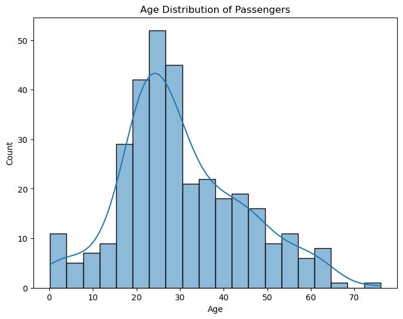

```python
plt.figure(figsize=(8, 6))
sns.histplot(df['Age'].dropna(), bins=20, kde=True)
plt.xlabel('Age')
plt.ylabel('Count')
plt.title('Age Distribution of Passengers')
plt.show()
```

# 3. How does the passenger class (Pclass) relate to survival rates?

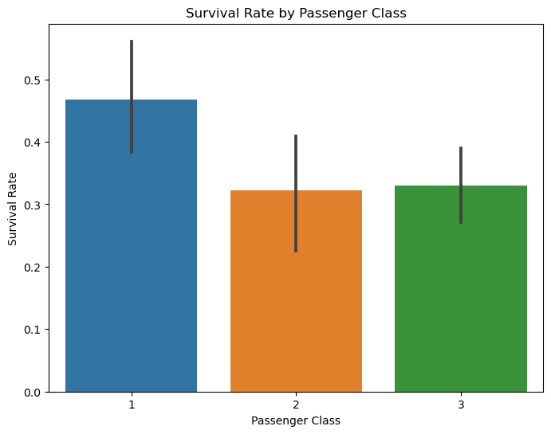

```python
plt.figure(figsize=(8, 6))
sns.barplot(x='Pclass', y='Survived', data=df)
plt.xlabel('Passenger Class')
plt.ylabel('Survival Rate')
plt.title('Survival Rate by Passenger Class')
plt.show()
```

# 4. Are there any correlations between features (e.g., age and fare)?

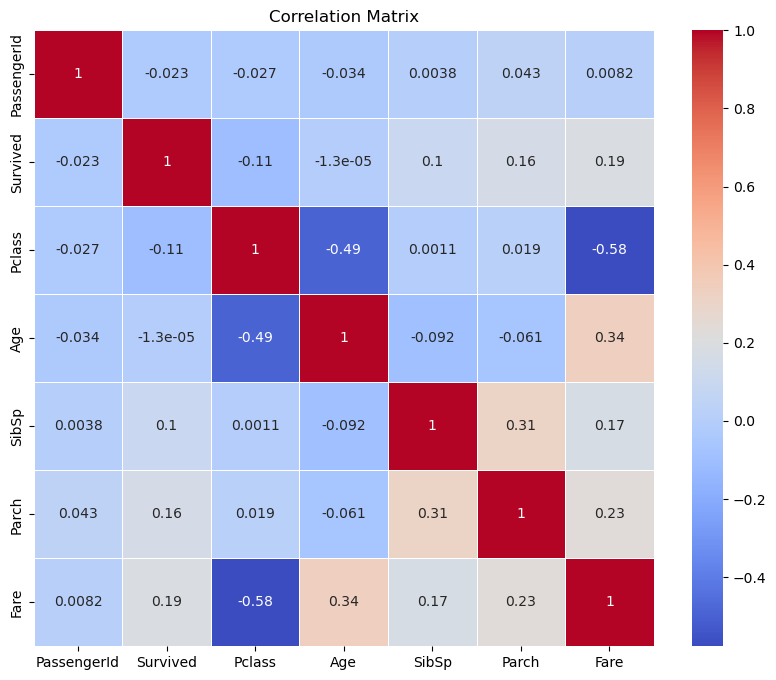

```python
correlation_matrix = df.corr()
plt.figure(figsize=(10, 8))
sns.heatmap(correlation_matrix, annot=True, cmap='coolwarm', linewidths=0.5)
plt.title('Correlation Matrix')
plt.show()
```

# Data Preprocessing:

# 5. How can we handle missing values in the dataset (e.g., age, cabin)?

# Handling Missing Values:

### To handle missing values in the dataset, you can consider the following approaches:

### For the 'Age' column, you can impute missing values with the mean, median, or a machine learning-based imputation technique like regression.

### For the 'Cabin' column, you can either drop it if it doesn't seem to provide valuable information, or create a new feature indicating whether the cabin information is missing or not.

### For the 'Embarked' column, which typically has very few missing values, you can either drop the rows with missing 'Embarked' values or impute them with the mode (most frequent value).

```python
median_age = df['Age'].median()
df['Age'].fillna(median_age, inplace=True)
```

```python
median_age
```

```
27.0
```

```python
df['Age']
```

```
0      34.5
1      47.0
2      62.0
3      27.0
4      22.0
       ...
413    27.0
414    39.0
415    38.5
416    27.0
417    27.0
Name: Age, Length: 418, dtype: float64
```

# 6. Can we create new features (e.g., family size) that might improve prediction?

# --- Creating new features can sometimes improve prediction. In this case, you mentioned "family size" as a potential new feature, which you can create by summing the 'SibSp' and 'Parch' columns.

```python
df['FamilySize'] = df['SibSp'] + df['Parch']
```

```python
df['FamilySize']
```

```
0      0
1      1
2      0
3      0
4      2
      ..
413    0
414    0
415    0
416    0
417    2
Name: FamilySize, Length: 418, dtype: int64
```

# Other potential new features could include extracting titles from the 'Name' column, which might indicate social status, or aggregating ticket information to find patterns

# 7. What strategies can we use to encode categorical variables (e.g., gender, embarked)?

### --> Categorical variables like 'Gender' and 'Embarked' need to be encoded numerically for machine learning algorithms. Common strategies include:

### One-Hot Encoding: Create binary columns for each category. For example, 'Gender' would become two columns, 'Male' and 'Female,' with binary values (0 or 1).

### Label Encoding: Assign a unique integer to each category. For 'Embarked,' 'C,' 'Q,' and 'S' might be assigned 0, 1, and 2, respectively.

```python
df = pd.get_dummies(df, columns=['Sex'], drop_first=True)
```

```python
df
```

|  | PassengerId | Survived | Pclass | Name | Age | SibSp | Parch | Ticket | Fare | Cabin | Embarked | FamilySize | Sex_male |
| --- | --- | --- | --- | --- | --- | --- | --- | --- | --- | --- | --- | --- | --- |
| 0 | 892 | 0 | 3 | Kelly, Mr. James | 34.5 | 0 | 0 | 330911 | 7.8292 | NaN | Q | 0 | 1 |
| 1 | 893 | 1 | 3 | Wilkes, Mrs. James (Ellen Needs) | 47.0 | 1 | 0 | 363272 | 7.0000 | NaN | S | 1 | 0 |
| 2 | 894 | 0 | 2 | Myles, Mr. Thomas Francis | 62.0 | 0 | 0 | 240276 | 9.6875 | NaN | Q | 0 | 1 |
| 3 | 895 | 0 | 3 | Wirz, Mr. Albert | 27.0 | 0 | 0 | 315154 | 8.6625 | NaN | S | 0 | 1 |
| 4 | 896 | 1 | 3 | Hirvonen, Mrs. Alexander (Helga E Lindqvist) | 22.0 | 1 | 1 | 3101298 | 12.2875 | NaN | S | 2 | 0 |
| ... | ... | ... | ... | ... | ... | ... | ... | ... | ... | ... | ... | ... | ... |
| 413 | 1305 | 0 | 3 | Spector, Mr. Woolf | 27.0 | 0 | 0 | A.5. 3236 | 8.0500 | NaN | S | 0 | 1 |
| 414 | 1306 | 1 | 1 | Oliva y Ocana, Dona. Fermina | 39.0 | 0 | 0 | PC 17758 | 108.9000 | C105 | C | 0 | 0 |
| 415 | 1307 | 0 | 3 | Saether, Mr. Simon Sivertsen | 38.5 | 0 | 0 | SOTON/O.Q. 3101262 | 7.2500 | NaN | S | 0 | 1 |
| 416 | 1308 | 0 | 3 | Ware, Mr. Frederick | 27.0 | 0 | 0 | 359309 | 8.0500 | NaN | S | 0 | 1 |
| 417 | 1309 | 0 | 3 | Peter, Master. Michael J | 27.0 | 1 | 1 | 2668 | 22.3583 | NaN | C | 2 | 1 |

418 rows × 13 columns

```python
from sklearn.preprocessing import LabelEncoder

label_encoder = LabelEncoder()
df['Embarked'] = label_encoder.fit_transform(df['Embarked'])
```

```python
df['Embarked']
```

```
0      1
1      2
2      1
3      2
4      2
      ..
413    2
414    0
415    2
416    2
417    0
Name: Embarked, Length: 418, dtype: int32
```

# Advanced Visualization:

## 8. How can we create a heatmap to visualize correlations between features?

### -->> Creating a Heatmap for Correlations:

```
To visualize correlations between features, you can create a heatmap using the seaborn library. This heatmap can help you identify which features are strongly correlated with each other and with the target variable ('Survived' in this case).
```

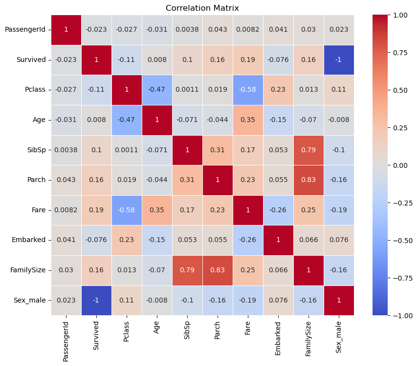

```python
import seaborn as sns
import matplotlib.pyplot as plt

correlation_matrix = df.corr()
plt.figure(figsize=(10, 8))
sns.heatmap(correlation_matrix, annot=True, cmap='coolwarm', linewidths=0.5)
plt.title('Correlation Matrix')
plt.show()
```

## This will display a heatmap where colors represent the strength and direction of correlations between features. Positive correlations are shown in one color, and negative correlations are shown in another color.

# 9. Can we use violin plots to compare age distributions among passengers in different classes?

### -->> Violin plots are great for comparing the distribution of a numerical variable (e.g., age) among different categories (e.g., passenger classes). You can use seaborn to create violin plots.

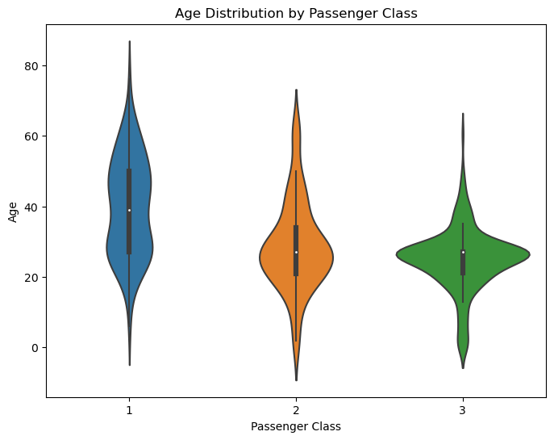

```python
plt.figure(figsize=(8, 6))
sns.violinplot(x='Pclass', y='Age', data=df)
plt.xlabel('Passenger Class')
plt.ylabel('Age')
plt.title('Age Distribution by Passenger Class')
plt.show()

# This will show violin plots for each passenger class, providing insights into the age distribution within each class.
```

# 10. What are the survival rate trends by age group?

### ---->>> To analyze survival rate trends by age group, you can group passengers into age bins and calculate the survival rate within each bin. You can then create a bar plot to visualize these trends.

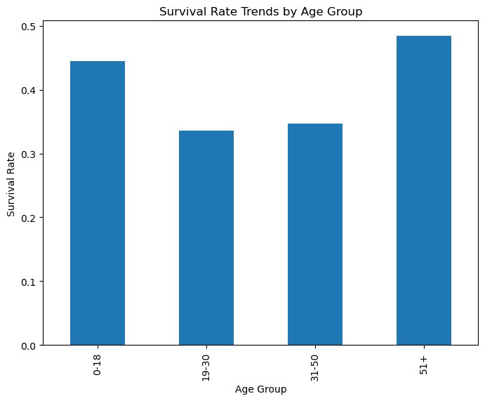

```python
# Define age bins
age_bins = [0, 18, 30, 50, np.inf]
age_labels = ['0-18', '19-30', '31-50', '51+']

# Create a new column for age groups
df['AgeGroup'] = pd.cut(df['Age'], bins=age_bins, labels=age_labels)

# Calculate survival rates by age group
age_group_survival = df.groupby('AgeGroup')['Survived'].mean()

# Plot the survival rates
plt.figure(figsize=(8, 6))
age_group_survival.plot(kind='bar')
plt.xlabel('Age Group')
plt.ylabel('Survival Rate')
plt.title('Survival Rate Trends by Age Group')
plt.show()
```

### # This code will group passengers into age categories and plot the survival rates for each age group, allowing you to observe survival trends across different age ranges. These visualizations can provide valuable insights into the relationships between features, age distributions by passenger class, and survival rate trends by age group in the Titanic dataset.

# Model Building:

## 11. What machine learning algorithms are suitable for predicting survival?

# --->>> Suitable Machine Learning Algorithms for Predicting Survival:

```
Several machine learning algorithms are suitable for predicting survival in the Titanic dataset. Some common choices include:
    Logistic Regression
    Decision Trees
    Random Forest
    Support Vector Machines (SVM)
    k-Nearest Neighbors (KNN)

The choice of algorithm should depend on factors such as the dataset size, complexity, and the specific goals of your analysis. It's often a good idea to try multiple algorithms and compare their performance.
```

# 12. How do we handle imbalanced classes in the target variable (survived vs. not survived)?

```python
#     Resampling:

#     Oversampling
#     Undersampling
#   Using Different Evaluation Metric
#   Ensemble Methods:
#   Collect More Data:
#   Algorithm Selection:
```

# 13. What hyperparameters should we tune for the selected classifier?

The hyperparameters you should tune for the selected classifier depend on the specific machine learning algorithm you choose. Here are some common hyperparameters to consider tuning for different classifiers:

1. Logistic Regression:

   Regularization strength (C): Controls the inverse of regularization strength. Smaller values increase regularization, which can help prevent overfitting.
2. Decision Trees and Random Forests:

   Maximum depth (max_depth): The maximum depth of the tree. Controls the model's complexity. Minimum samples per leaf (min_samples_leaf): The minimum number of samples required to be in a leaf node. Minimum samples per split (min_samples_split): The minimum number of samples required to split an internal node. Number of estimators (Random Forest only): The number of trees in the forest. Maximum features (Random Forest only): The maximum number of features to consider when splitting a node.
3. Support Vector Machines (SVM):

   Regularization parameter (C): Controls the trade-off between maximizing the margin and minimizing the classification error. Kernel choice (kernel): Specifies the kernel function to be used (e.g., linear, polynomial, radial basis function).
4. k-Nearest Neighbors (KNN):

   Number of neighbors (n_neighbors): The number of nearest neighbors to consider when making predictions. Distance metric (metric): The distance metric used to measure the distance between data points (e.g., Euclidean, Manhattan).
1. Ensemble Methods (e.g., AdaBoost, GradientBoostingClassifier):

   Base estimator: The classifier used as the base model (e.g., DecisionTreeClassifier). Number of estimators: The number of weak learners in the ensemble. Learning rate: Controls the contribution of each weak learner.

When tuning hyperparameters, you can use techniques like grid search or random search to explore a range of values for each hyperparameter and find the combination that optimizes your chosen evaluation metric (e.g., accuracy, F1-score, ROC AUC) through cross-validation.

Remember that the optimal hyperparameters can vary depending on your specific dataset and problem. It's essential to experiment with different combinations of hyperparameters and evaluate their impact on model performance to find the best configuration for your particular task.

# 14. Can we use feature scaling or normalization to improve model performance?

#### 1. Algorithms That Require Feature Scaling:

```
Some machine learning algorithms are sensitive to the scale of features and may benefit from feature scaling. These algorithms include:
    Support Vector Machines (SVM)
    k-Nearest Neighbors (KNN)

Feature scaling can help these algorithms converge faster and improve their performance.
```

1. Common Methods for Feature Scaling:

   There are two common methods for feature scaling:

   ```
    Standardization (Z-score normalization): This method scales features to have a mean of 0 and a standard deviation of 1. It's suitable when features have roughly Gaussian distributions and ensures that features have similar scales.

    Min-Max Scaling (Normalization): This method scales features to a specified range, typically [0, 1]. It's useful when you want features to have a specific numeric range.
   ```

```
#    For standardization (Z-score normalization):

Standardization scales features to have a mean of 0 and a standard deviation of 1. It is suitable when features have roughly Gaussian distributions and ensures that features have similar scales.
```

You can use the StandardScaler class from scikit-learn to standardize features

```python
from sklearn.preprocessing import StandardScaler

# Create an instance of the StandardScaler class
x = df[['PassengerId', 'Survived', 'Pclass', 'Age']]

# Create an instance of the StandardScaler class
scaler = StandardScaler()

# Fit the scaler to your feature matrix and transform the features
X_scaled = scaler.fit_transform(x)
```

```python
X_scaled
```

```
array([[-1.72791209, -0.75592895,  0.87348191,  0.38623105],
       [-1.71962474,  1.32287566,  0.87348191,  1.37137004],
       [-1.71133739, -0.75592895, -0.31581919,  2.55353683],
       ...,
       [ 1.71133739, -0.75592895,  0.87348191,  0.70147553],
       [ 1.71962474, -0.75592895,  0.87348191, -0.20485235],
       [ 1.72791209, -0.75592895,  0.87348191, -0.20485235]])
```

```python
from sklearn.preprocessing import MinMaxScaler

# Create an instance of the MinMaxScaler class
scaler = MinMaxScaler()

# Fit the scaler to your feature matrix and transform the features
X_scaled = scaler.fit_transform(x)
```

# Model Evaluation:

# 15. How can we evaluate the model's performance using cross-validation?

# Import the Necessary Libraries:

```python
from sklearn.model_selection import cross_val_score
from sklearn.metrics import accuracy_score, precision_score, recall_score, f1_score
```

# Split Your Dataset

```python
x = df.drop(['Survived'], axis=1)
y = df['Survived']
```

```python
x
```

|  | PassengerId | Pclass | Name | Age | SibSp | Parch | Ticket | Fare | Cabin | Embarked | FamilySize | Sex_male | AgeGroup |
| --- | --- | --- | --- | --- | --- | --- | --- | --- | --- | --- | --- | --- | --- |
| 0 | 892 | 3 | Kelly, Mr. James | 34.5 | 0 | 0 | 330911 | 7.8292 | NaN | 1 | 0 | 1 | 31-50 |
| 1 | 893 | 3 | Wilkes, Mrs. James (Ellen Needs) | 47.0 | 1 | 0 | 363272 | 7.0000 | NaN | 2 | 1 | 0 | 31-50 |
| 2 | 894 | 2 | Myles, Mr. Thomas Francis | 62.0 | 0 | 0 | 240276 | 9.6875 | NaN | 1 | 0 | 1 | 51+ |
| 3 | 895 | 3 | Wirz, Mr. Albert | 27.0 | 0 | 0 | 315154 | 8.6625 | NaN | 2 | 0 | 1 | 19-30 |
| 4 | 896 | 3 | Hirvonen, Mrs. Alexander (Helga E Lindqvist) | 22.0 | 1 | 1 | 3101298 | 12.2875 | NaN | 2 | 2 | 0 | 19-30 |
| ... | ... | ... | ... | ... | ... | ... | ... | ... | ... | ... | ... | ... | ... |
| 413 | 1305 | 3 | Spector, Mr. Woolf | 27.0 | 0 | 0 | A.5. 3236 | 8.0500 | NaN | 2 | 0 | 1 | 19-30 |
| 414 | 1306 | 1 | Oliva y Ocana, Dona. Fermina | 39.0 | 0 | 0 | PC 17758 | 108.9000 | C105 | 0 | 0 | 0 | 31-50 |
| 415 | 1307 | 3 | Saether, Mr. Simon Sivertsen | 38.5 | 0 | 0 | SOTON/O.Q. 3101262 | 7.2500 | NaN | 2 | 0 | 1 | 31-50 |
| 416 | 1308 | 3 | Ware, Mr. Frederick | 27.0 | 0 | 0 | 359309 | 8.0500 | NaN | 2 | 0 | 1 | 19-30 |
| 417 | 1309 | 3 | Peter, Master. Michael J | 27.0 | 1 | 1 | 2668 | 22.3583 | NaN | 0 | 2 | 1 | 19-30 |

418 rows × 13 columns

```python
y
```

```
0      0
1      1
2      0
3      0
4      1
      ..
413    0
414    1
415    0
416    0
417    0
Name: Survived, Length: 418, dtype: int64
```

## Choose a Machine Learning Model:

### Select the machine learning model you want to evaluate. Ensure that you have already trained and fine-tuned your model using a separate training dataset

```python
from sklearn import preprocessing
for col in df.select_dtypes(include=['object']).columns:

    print(f"{col}:{df[col].unique()}")
```

[output not shown]

[output cut: 230 more lines]

[output not shown]

```python
for col in df.select_dtypes(include=['object']).columns:

    label_encoder=preprocessing.LabelEncoder()
    label_encoder.fit(df[col].unique())

    df[col]=label_encoder.transform(df[col])

    print(f"(col):{df[col].unique()}")
```

[output not shown]

[output cut: 34 more lines]

```python
x = df.drop(['Survived', 'AgeGroup'], axis=1)
y = df['Survived']
```

```python
x.columns
```

```
Index(['PassengerId', 'Pclass', 'Name', 'Age', 'SibSp', 'Parch', 'Ticket',
       'Fare', 'Cabin', 'Embarked', 'FamilySize', 'Sex_male'],
      dtype='object')
```

```python
x.isnull().sum()
```

```
PassengerId    0
Pclass         0
Name           0
Age            0
SibSp          0
Parch          0
Ticket         0
Fare           1
Cabin          0
Embarked       0
FamilySize     0
Sex_male       0
dtype: int64
```

```python
x.fillna(x.median(),inplace=True)
```

```python
from sklearn.model_selection import train_test_split
from sklearn.ensemble import RandomForestClassifier  # Replace with your chosen model

# Split your dataset into a training set and a validation set
x_train, x_valid, y_train, y_valid = train_test_split(x, y, test_size=0.2, random_state=42)

# Create and train your machine learning model
model = RandomForestClassifier()  # Replace with your chosen model
model.fit(x_train, y_train)
```

```
RandomForestClassifier()
```

```python
# Perform Cross-Validation:

# Use the cross_val_score function from scikit-learn to perform k-fold cross-validation.
# Specify the model, feature matrix, target variable, and the number of folds (k).
```

```python
# Specify the number of folds (k)
k = 5  # You can choose the desired number of folds

# Perform k-fold cross-validation
scores = cross_val_score(model, x, y, cv=k)
```

```python
scores
```

```
array([1., 1., 1., 1., 1.])
```

# Evaluate Model Performance:

Compute various evaluation metrics on the cross-validation results. You can calculate metrics such as accuracy, precision, recall, and F1-score for classification tasks, or mean squared error (MSE) for regression tasks.

```python
# Calculate mean accuracy and standard deviation of accuracy
mean_accuracy = scores.mean()
std_accuracy = scores.std()

# Print the mean accuracy and its standard deviation
print(f"Mean Accuracy: {mean_accuracy:.2f}")
print(f"Standard Deviation of Accuracy: {std_accuracy:.2f}")
```

```
Mean Accuracy: 1.00
Standard Deviation of Accuracy: 0.00
```

# 16. What other metrics besides accuracy should be considered for evaluation?

```python
# While accuracy is a commonly used metric for evaluating the performance of classification models,
# it may not always provide a complete picture, especially when dealing with imbalanced datasets or
#  when different types of errors have different consequences. To gain a more comprehensive understanding
#  of model performance, consider these additional metrics for evaluation:

#  Precision: Precision measures the proportion of true positive predictions among all positive
#  predictions made by the model. It is a useful metric when minimizing false positives is crucial.
#For example, in medical diagnosis, precision is essential because false positives can lead to unnecessary treatments or stress.

#     Formula: Precision = TP / (TP + FP)

#  Recall (Sensitivity or True Positive Rate): Recall measures the proportion of true positive predictions
#    among all actual positive instances. It is valuable when identifying as many positive cases as possible is essential.
#   For instance, in disease detection, high recall ensures that no true cases are missed.

#     Formula: Recall = TP / (TP + FN)

# F1-Score: The F1-Score is the harmonic mean of precision and recall. It provides a balance between precision and recall,
#  making it useful when you want to consider both false positives and false negatives. A higher F1-Score indicates
#  better overall model performance.

#   Formula: F1-Score = 2 * (Precision * Recall) / (Precision + Recall)

#   Confusion Matrix: A confusion matrix displays the number of true positives, true negatives, false positives,
#  and false negatives. It's a valuable tool for understanding the distribution of prediction outcomes and can be
#    used to calculate many of the metrics mentioned above.
```

# 17. How do we interpret precision, recall, and F1-score in the context of survival prediction?

```python
#  In the context of survival prediction, precision, recall, and F1-score are important evaluation metrics that provide
#  insights into the performance of a machine learning model. Here's how to interpret these metrics in the context
#   of survival prediction:

#    Precision:

#        Interpretation: Precision measures the proportion of correctly predicted survivors among all the instances
#                     predicted as survivors by the model.
#       Context: A high precision indicates that when the model predicts an individual as a survivor,
#               it is likely to be correct. In other words, the model minimizes false positive predictions of survival.
#      Importance: Precision is crucial when making predictions has consequences, such as resource allocation for
#                  rescue operations. High precision means fewer resources wasted on false positives.

#  Recall (Sensitivity):
#            Interpretation: Recall measures the proportion of correctly predicted survivors among all the actual
#                                 survivors in the dataset.
#           Context: High recall implies that the model is good at capturing most of the actual survivors.
#                    It minimizes false negatives, ensuring that a high percentage of survivors are correctly identified.
#         Importance: Recall is essential when identifying survivors is critical, such as in medical diagnoses or
#                          search and rescue operations. High recall ensures that very few true survivors are missed.

#    F1-Score:
#           Interpretation: The F1-Score is the harmonic mean of precision and recall. It provides a balance between
#                               the two metrics.
#         Context: F1-Score considers both false positives (precision) and false negatives (recall). It represents a
#                       trade-off between identifying as many survivors as possible while avoiding false alarms.
#          Importance: F1-Score is useful when there is an inherent trade-off between precision and recall,
#                      and you want to strike a balance between minimizing false positives and false negatives.
```

# Advanced Analysis:

# 18. How can we apply feature engineering to improve model performance (e.g., title extraction from names)?

## Feature engineering is a crucial step in improving model performance by creating new features or transforming existing ones to provide more valuable information to the model. In the context of survival prediction for the Titanic dataset, here are some feature engineering techniques you can apply:

## Title Extraction from Names:

### Extract titles (e.g., Mr., Mrs., Miss, etc.) from passenger names. Titles can provide information about social status and gender, which might be relevant for survival prediction.

### Group rare or similar titles into broader categories to reduce feature dimensionality.

### Family Size: Create a new feature that represents family size by combining the number of siblings/spouses (SibSp) and parents/children (Parch) on board. Larger families might have different survival rates.

#### Alone Status: Create a binary feature to indicate whether a passenger is traveling alone (1) or with family (0). Solo travelers might have different survival characteristics.

### Cabin Deck: Extract the deck information from the cabin numbers. Passengers on certain decks may have been closer to lifeboats, impacting their survival chances.

### Ticket Prefix: Extract prefixes from ticket numbers. Some prefixes may indicate group bookings or special arrangements.

### Age Binning: Group passengers into age bins (e.g., children, adults, seniors) to capture nonlinearities in age-related survival rates.

### Fare Binning: Group fares into bins to capture variations in fare ranges and reduce the impact of extreme values.

### Name Length: Create a feature representing the length of passenger names. Longer names might indicate a higher social status.

### Age * Class Interaction: Create a new feature by multiplying age and passenger class (Pclass). This captures the interaction between age and class in survival prediction.

### Title * Age Interaction: Create a new feature by multiplying passenger titles and age. This may capture unique age-related survival patterns for different titles.

### Age Group * Pclass Interaction: Create an interaction feature that combines age groups and passenger class. This might capture survival trends specific to age groups within each class.

### One-Hot Encoding: Encode categorical variables such as gender (sex) and port of embarkation (embarked) using one-hot encoding.

### Missing Value Handling: Handle missing values in features like age and cabin. You can impute missing values with median values or use more advanced techniques like regression imputation.

### Log Transformation: If necessary, apply log transformation to features with skewed distributions to make them more suitable for modeling.

After creating these engineered features, it's essential to assess their impact on model performance through experimentation and cross-validation. Some features may significantly improve the model, while others may not add value or might introduce noise. Feature engineering is an iterative process, and you should continuously evaluate and refine your features to achieve the best model performance.

# 19. Can we build an ensemble of models for better predictive accuracy?

# Yes, building an ensemble of models is a common and effective approach to improve predictive accuracy in machine learning. Ensembling combines the predictions of multiple individual models to make more accurate and robust predictions. In the context of survival prediction for the Titanic dataset, you can certainly build an ensemble of models to achieve better predictive accuracy.

Here are some ensemble techniques you can consider:

```
Voting Ensemble:
    Create an ensemble of multiple machine learning models (e.g., decision trees, random forests, support vector machines, logistic regression).
    Use majority voting (for classification) to make final predictions. Each model gets one vote, and the class with the most votes is the predicted class.

Bagging (Bootstrap Aggregating):
    Bagging involves training multiple instances of the same model on different subsets of the training data.
    Popular algorithms like Random Forests use bagging by training multiple decision trees on bootstrapped subsets of the data and combining their predictions.

Boosting:
    Boosting focuses on training multiple weak learners (e.g., shallow decision trees) sequentially, with each learner correcting the errors of the previous one.
    Algorithms like AdaBoost and Gradient Boosting are common boosting techniques.

Stacking:
    Stacking combines the predictions of multiple models by training a meta-model (often a simple linear model) on their outputs.
    It involves a two-level architecture: base models at the first level and a meta-model at the second level.

XGBoost and LightGBM:
    XGBoost (Extreme Gradient Boosting) and LightGBM are gradient boosting libraries known for their high predictive accuracy.
    They can be used as standalone models or as part of an ensemble.

Ensemble with Feature Selection:
    Combine models while selecting only the most important features for each model. This can help improve predictive accuracy while reducing dimensionality.

Ensemble with Different Algorithms:
    Combine models that use different algorithms to capture different patterns in the data.
    For example, combine a tree-based model (e.g., Random Forest) with a linear model (e.g., Logistic Regression).

Ensemble with Hyperparameter Tuning:
    Perform hyperparameter tuning for each model in the ensemble to optimize their individual performance.

Ensemble with Model Stacking:
    Create multiple levels of ensembling by stacking multiple layers of models on top of each other.
    This can be computationally expensive but may provide further performance gains.
```

When building an ensemble of models, it's important to ensure diversity among the base models. Diversity in terms of algorithms, hyperparameters, and feature subsets can lead to more robust and accurate ensemble predictions.

Additionally, you should use cross-validation to evaluate the performance of your ensemble. Cross-validation helps assess how well the ensemble generalizes to unseen data and can guide the selection of the best combination of models and techniques for your specific problem.

Ensembling is a powerful technique that often leads to improved predictive accuracy, making it a valuable tool for tackling complex machine learning tasks like survival prediction on the Titanic dataset.

# 20. What techniques can we use for interpreting and visualizing model predictions?

Interpreting and visualizing model predictions are essential steps in understanding how a machine learning model makes decisions and gaining insights into its behavior. Here are some techniques and tools you can use to interpret and visualize model predictions:

1. Feature Importance:

   Techniques:

   ```
    For tree-based models (e.g., Random Forest, Decision Trees), you can calculate feature importance scores, which indicate the influence of each feature on model predictions.
    Permutation Importance: Shuffle the values of a feature and measure how much it affects the model's performance.
    SHAP (SHapley Additive exPlanations): SHAP values provide a unified measure of feature importance for a wide range of models.
   ```

   Visualization:

   ```
    Create bar charts or heatmaps to visualize feature importance scores.
    Plot individual SHAP values to understand the impact of each feature on specific predictions.
   ```

2. Partial Dependence Plots (PDP):

   Techniques:

   ```
    PDPs show how a feature's values affect model predictions while keeping other features constant. They help reveal the relationship between a feature and the predicted outcome.
   ```

   Visualization:

   ```
    Plot PDPs for selected features to visualize how they influence predictions.
   ```

3. Residual Plots:

   Techniques:

   ```
    For regression models, residual plots show the distribution of residuals (the difference between predicted and actual values). Patterns in residuals can provide insights into model performance.
   ```

   Visualization:

   ```
    Create scatter plots or histograms of residuals to check for patterns or heteroscedasticity.
   ```

4. Confusion Matrix:

   Techniques:

   ```
    For classification models, confusion matrices provide a breakdown of true positives, true negatives, false positives, and false negatives.
   ```

   Visualization:

   ```
    Create a heatmap or a table to display the confusion matrix.
   ```

5. ROC Curve and Precision-Recall Curve:

   Techniques:

   ```
    ROC curves and precision-recall curves help assess the trade-off between true positive rate and false positive rate at different probability thresholds.
   ```

   Visualization:

   ```
    Plot ROC curves and precision-recall curves to assess model performance.
   ```

6. LIME (Local Interpretable Model-agnostic Explanations):

   Techniques:

   ```
    LIME generates local explanations for individual predictions by fitting a simpler interpretable model to a neighborhood of data points.
   ```

   Visualization:

   ```
    Visualize LIME explanations to understand why the model made a specific prediction for a particular instance.
   ```

7. SHAP Plots:

   Techniques:

   ```
    SHAP values can be used to create summary plots that show the overall impact of features on model predictions across a dataset.
   ```

   Visualization:

   ```
    Plot summary SHAP values to see how features contribute to model predictions globally.
   ```

8. Grad-CAM (Gradient-weighted Class Activation Mapping):

   Techniques:

   ```
    For image classification models, Grad-CAM highlights the regions of an image that contribute most to the model's prediction.
   ```

   Visualization:

   ```
    Overlay the Grad-CAM heatmap on the input image to visualize which areas the model focused on.
   ```

9. Model Explanations Libraries:

   Techniques:

   ```
    Various Python libraries, such as interpret, shap, lime, and eli5, offer pre-built tools for interpreting model predictions.
   ```

   Visualization:

   ```
    These libraries often come with built-in visualization functions to simplify interpretation.
   ```

10. Feature Importance for Regression Coefficients:

    Techniques:

    ```
    For linear regression models, examine the coefficients associated with each feature to understand their impact on the target variable.
    ```

    Visualization:

    ```
    Create a bar chart or table to display the feature coefficients.
    ```

These techniques and tools can help you gain insights into your model's behavior, identify potential issues, and improve model transparency. The choice of interpretation and visualization methods depends on the type of model, the nature of the data, and the specific questions you want to answer about your machine learning model's predictions.